# IST 687 Final Project

# Data Visualizations

## Applicant Gender

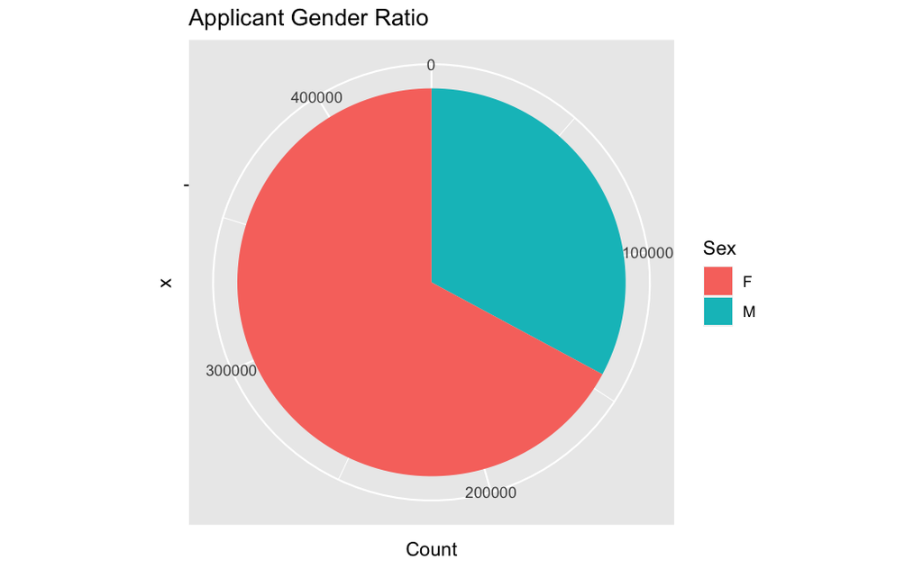

```r
# ------------ Gender (Pie Chart) ------------
male <- length(which(cc_app_data$CODE_GENDER == "M"))
female <- length(which(cc_app_data$CODE_GENDER == "F"))

m_f_df <- data.frame(c("M","F"),c(male,female))
colnames(m_f_df) <- c("Sex","Count")

# Male/Female Pie chart
ggplot(m_f_df, aes(x="", y=Count, fill=Sex)) +
  geom_bar(stat="identity", width=1) +
  coord_polar("y", start=0) + ggtitle("Applicant Gender Ratio")
```

```r
male_pct <- male/(male+female)
female_pct <- female/(male+female)
```

67.14% of our applicants are female whereas 32.86% are male

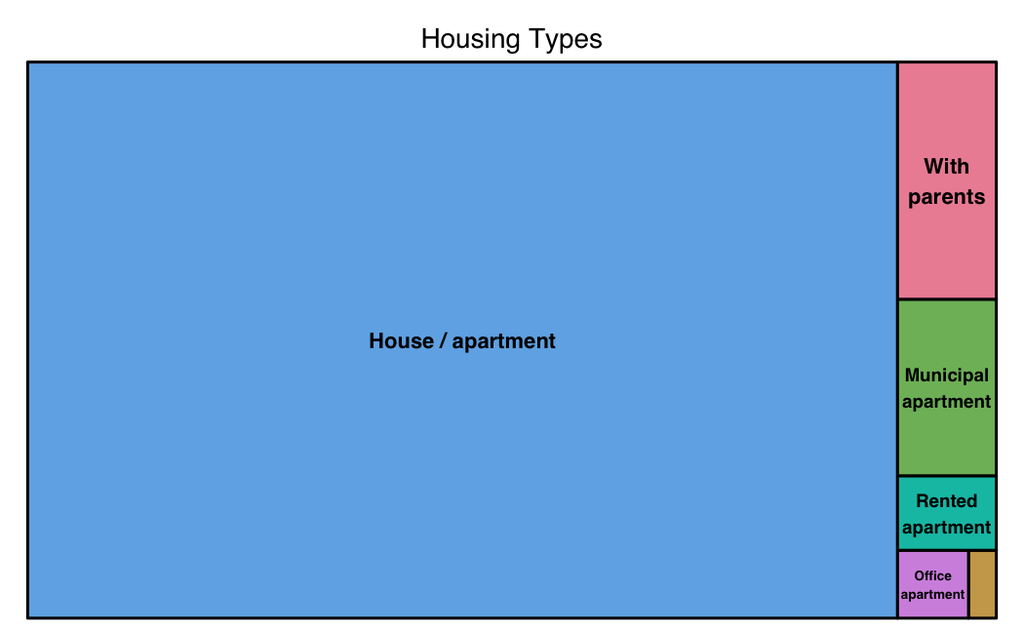

```r
# Get list of unique values from the column
housing_types <- unique(cc_app_data$NAME_HOUSING_TYPE)

# Create empty vector to hold counts of each value
housing_type_counts <- c()

# Append the counts of each unique value to the housing_type_counts vector
for (i in housing_types){
  type_count <- length(which(cc_app_data$NAME_HOUSING_TYPE == i))
  housing_type_counts <- c(housing_type_counts,type_count)
}


# ------------ Housing Type (Tree Map)  ------------
housing_type_data <- data.frame(housing_types,housing_type_counts)

# Housing Type Tree map
treemap(housing_type_data,
            index="housing_types",
            vSize="housing_type_counts",
            type="index",
            title = "Housing Types"
            )
```

```r
NA
NA
```

```r
cloud_count <- count(cc_app_data, OCCUPATION_TYPE)

wordcloud2(data=cloud_count, size=1.6)
```

[interactive chart not shown]

In the word cloud above, we see that Laborers, Sales Staff, Managers, and Core Staff make up the majority of our applicant’s Occupation Type.

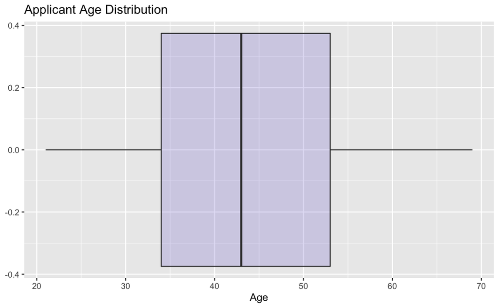

```r
# Age box plot
ggplot(cc_app_data, aes(x=Age)) +
    geom_boxplot(fill="slateblue", alpha=0.2) + ggtitle("Applicant Age Distribution")
```

The median age of our applicants is 43 years old. 25% of our applicants are between 21 and 34 years old. 50% of our applicants are between 21 and 43 years old. 75% of our applicants are between 21 and 53 years old. There appears to be no outliers in our data, with respect to age.s

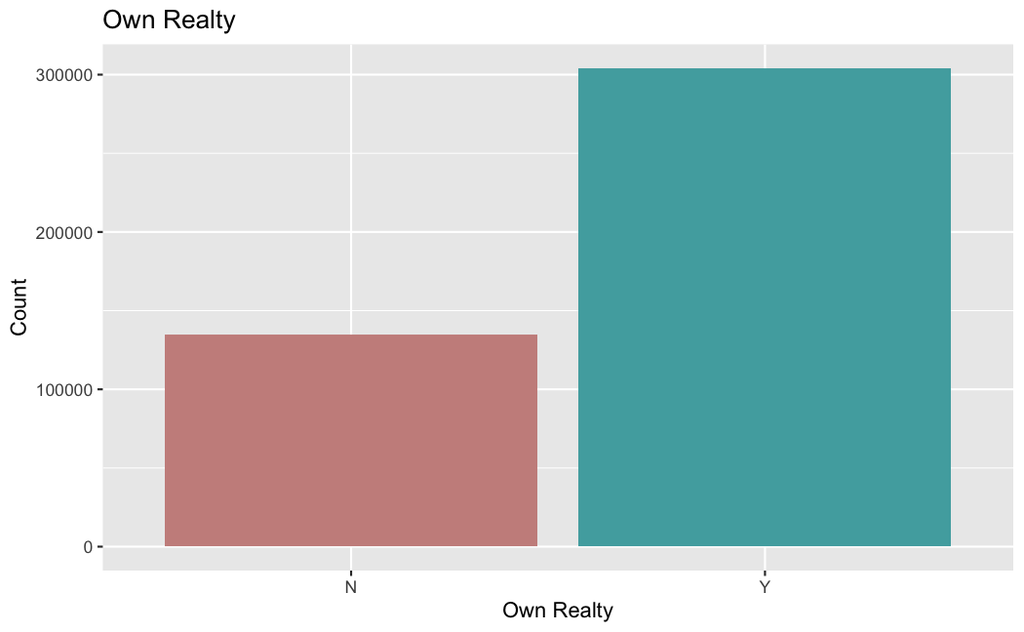

```r
# Own Realty Column Chart
own_realty <- length(which(cc_app_data$FLAG_OWN_REALTY == "Y"))
do_not_own_realty <- length(which(cc_app_data$FLAG_OWN_REALTY == "N"))

ggplot(cc_app_data, aes(x=as.factor(FLAG_OWN_REALTY), fill=as.factor(FLAG_OWN_REALTY) )) +
  geom_bar( ) +
  scale_fill_hue(c = 40) +
  theme(legend.position="none") +
  ylab("Count") +
  xlab("Own Realty") +
  ggtitle("Own Realty")
```

More than twice as many applicants own realty than those who do not; 69.34% own realty whereas 30.66% do not own realty.

## Define logic for approval and line of credit

```r
# ----------------  Approval and Line of Credit Logic  -----------------

approval_check <- function(application){
  # Declare Base score of 0
  base_score <- 0

  # Declare Base APR
  base_APR <- 5
  additional_APR <- 0.5

  # Establish Tier of Income
  T1 <- 250000
  T2 <- 500000
  T3 <- 750000
  T4 <- 1000000

  # Establish line of credit rates
  T1_rate <-  0.01
  T2_rate <-  0.05
  T3_rate <-  0.10
  T4_rate <-  0.15

  # Pull out variables that are to be considered
  applicant_ID <- application[1]
  applicant_income <- as.numeric(application[6])
  applicant_house_type <- application[10]
  applicant_own_car <- application[3]
  applicant_own_realty <- application[4]
  applicant_count_of_children <- as.numeric(application[5])

  # Determine Applicant Tier and Points for Tier
  applicant_tier <- "No Tier"
  base_income <- 20000

  if(applicant_income <= T1 & applicant_income >= base_income){
    applicant_tier <- "T1"
    base_score <- base_score + 12.5

  } else if (applicant_income > T1 & applicant_income <= T2){
    applicant_tier <- "T2"
    base_score <- base_score + (12.5*2)

  } else if (applicant_income > T2 & applicant_income <= T3){
    applicant_tier <- "T3"
    base_score <- base_score + (12.5*3)

  } else if (applicant_income > T3 & applicant_income <= T4){
    applicant_tier <- "T4"
    base_score <- base_score + (12.5*4)

  } else {
    applicant_tier <- "Insuffienct Income"
    base_score <- 0
  }

  # Determine House Type and Own/Rent Score
  if (applicant_house_type == "House / apartment" & applicant_own_realty == "Y"){
    base_score <- base_score + 25 + 10
  } else if (applicant_house_type == "House / apartment" & applicant_own_realty == "N") {
    base_score <- base_score + 12.5 + 7
  } else if (applicant_house_type == "With parents" & applicant_own_realty == "Y") {
    base_score <- base_score + 25 + 7
  } else if (applicant_house_type == "With parents" & applicant_own_realty == "N") {
    base_score <- base_score + 12.5 + 5
  } else if (applicant_house_type == "Municipal apartment" & applicant_own_realty == "Y") {
    base_score <- base_score + 25 + 4
  } else if (applicant_house_type == "Municipal apartment" & applicant_own_realty == "N") {
    base_score <- base_score + 12.5 + 4
  } else if (applicant_house_type == "Rented apartment" & applicant_own_realty == "Y") {
    base_score <- base_score + 25 + 10
  } else if (applicant_house_type == "Rented apartment" & applicant_own_realty == "N") {
    base_score <- base_score + 12.5 + 6
  } else if (applicant_house_type == "Office apartment" & applicant_own_realty == "Y") {
    base_score <- base_score + 25 + 10
  } else if (applicant_house_type == "Office apartment" & applicant_own_realty == "N") {
    base_score <- base_score + 12.5 + 5
  } else if (applicant_house_type == "Co-op apartment" & applicant_own_realty == "Y") {
    base_score <- base_score + 25 + 10
  } else if (applicant_house_type == "Co-op apartment" & applicant_own_realty == "N") {
    base_score <- base_score + 20 + 6
  } else {
    base_score <- base_score + 0
  }

  # Determine car ownership score
  if (applicant_own_car == "Y"){
    base_score <- base_score + 5
  } else if (applicant_own_car == "N"){
    base_score <- base_score + 2.5
  } else {
    base_score <- base_score + 0
  }

  # Determine score for number of children
  if (applicant_count_of_children == 0){
    base_score <- base_score + 10
  } else if (applicant_count_of_children == 1){
    base_score <- base_score + 9
  } else if (applicant_count_of_children == 2){
    base_score <- base_score + 8
  } else if (applicant_count_of_children == 3){
    base_score <- base_score + 7
  } else if (applicant_count_of_children >= 4 & applicant_count_of_children <= 6){
    base_score <- base_score + 5
  } else if (applicant_count_of_children >= 7 & applicant_count_of_children <= 10){
    base_score <- base_score + 3
  } else if (applicant_count_of_children < 10){
    base_score <- base_score + 1
  }

  # Determine if applicant is approved
  approval <- NA

  if(base_score >= 50){
    approval <- "Approved"
  } else {
    approval <- "Denied"
  }


  # Establish Line of Credit Amount
  line_of_credit <- 0

  # Determine Line of Credit
  if(applicant_tier == "T1" & approval == "Approved"){
    line_of_credit <- applicant_income*T1_rate
  } else if (applicant_tier == "T2" & approval == "Approved") {
    line_of_credit <- applicant_income*T2_rate
  } else if (applicant_tier == "T3" & approval == "Approved") {
    line_of_credit <- applicant_income*T3_rate
  } else if (applicant_tier == "T4" & approval == "Approved") {
    line_of_credit <- applicant_income*T4_rate
  } else {
    line_of_credit <- 0
  }

  # Set APR to 0
  applicant_APR <- 0

  # Determine APR
  if(base_score == 100 & approval == "Approved"){
    applicant_APR <- base_APR
  } else if (base_score < 100 & approval == "Approved"){
    APR_multiplier <- 100 - base_score
    applicant_APR <- base_APR + (APR_multiplier * additional_APR)
  }

  approval_vector <- NULL

  if(approval == "Approved"){
    approval_vector <- c(approval,line_of_credit,applicant_APR)
  } else {
    approval_vector <- c(approval,NA,NA)
  }

  return(approval_vector)


}
```

## Process the Applications

```r
# # ----------------  Application Processing  -----------------
#
# # Create Empty Vectors to hold data for new columns
# approval_col <- c()
# credit_col <- c()
# apr_col <- c()
#
#
# # Loop through rows and determine approval, credit line, and APR
# for(i in 1:nrow(cc_app_data)){
#   application_data <- as.vector(as.character(cc_app_data[i,]))
#   result <- approval_check(application_data)
#   approval_col <- c(approval_col,result[1])
#   credit_col <- c(credit_col,result[2])
#   apr_col <- c(apr_col,result[3])
#
# }
#
# # Save data to new DF
# application_results <- cc_app_data
#
# # Add new columns with results
# application_results$Approval_Status <- approval_col
# application_results$Line_of_Credit <- as.numeric(credit_col)
# application_results$APR <- as.numeric(apr_col)/100
#
# # Preview data
# head(application_results)
#
#
# write_xlsx(application_results, "application_results.xlsx")
```

## Analyze results of application processing

```r
# Read in the Excel
application_results <- read_excel('application_results.xlsx')

head(application_results)
```

| ID | CODE_GENDER | FLAG_OWN_CAR | FLAG_OWN_REALTY | CNT_CHILDREN | AMT_INCOME_TOTAL | NAME_INCOME_TYPE | NAME_EDUCATION_TYPE | NAME_FAMILY_STATUS | NAME_HOUSING_TYPE | Age | DAYS_EMPLOYED | FLAG_MOBIL | FLAG_WORK_PHONE | FLAG_EMAIL | OCCUPATION_TYPE | CNT_FAM_MEMBERS | Approval_Status | Line_of_Credit | APR |
| --- | --- | --- | --- | --- | --- | --- | --- | --- | --- | --- | --- | --- | --- | --- | --- | --- | --- | --- | --- |
| 6093713 | F | N | N | 0 | 26100 | Pensioner | Secondary / secondary special | Married | House / apartment | 58 | 365243 | 1 | 0 | 0 | NA | 2 | Denied | NA | NA |
| 6093712 | F | N | N | 0 | 26100 | Pensioner | Secondary / secondary special | Married | House / apartment | 58 | 365243 | 1 | 0 | 0 | NA | 2 | Denied | NA | NA |
| 5126174 | F | N | N | 0 | 27000 | Working | Higher education | Civil marriage | House / apartment | 41 | -5067 | 1 | 1 | 0 | Managers | 2 | Denied | NA | NA |
| 5126175 | F | N | N | 0 | 27000 | Working | Higher education | Civil marriage | House / apartment | 41 | -5067 | 1 | 1 | 0 | Managers | 2 | Denied | NA | NA |
| 5995345 | F | N | N | 0 | 27000 | Working | Higher education | Civil marriage | House / apartment | 41 | -5067 | 1 | 1 | 0 | Managers | 2 | Denied | NA | NA |
| 5143327 | F | N | Y | 0 | 27000 | Working | Secondary / secondary special | Married | House / apartment | 52 | -1323 | 1 | 1 | 0 | Security staff | 2 | Approved | 270 | 0.25 |

```r
approved_df = application_results[application_results$Approval_Status == "Approved",]
declined_df = application_results[application_results$Approval_Status == "Denied",]
```

```r
summary(application_results$AMT_INCOME_TOTAL)
```

```
   Min. 1st Qu.  Median    Mean 3rd Qu.    Max.
  26100  121500  160780  187524  225000 6750000
```

## Results Visualizations

```r
results_cloud_count <- count(approved_df, OCCUPATION_TYPE)

wordcloud2(data=results_cloud_count, size=1.6)
```

[interactive chart not shown]

```r
NA
```

In the above word cloud, we see that the top applicants that were approved were Laborers, Sales Staff, and Core Staff.

```r
approved_male + approved_female
```

```
[1] 326947
```

```r
overall_approval_pct <- (approved_male + approved_female) / 438557
total_approvals <- approved_male + approved_female
```

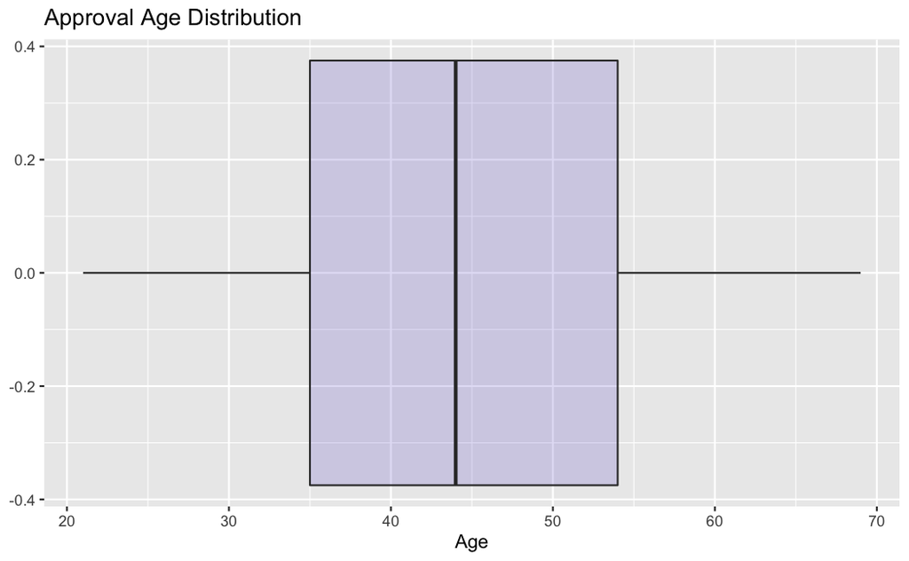

```r
# Age box plot
ggplot(approved_df, aes(x=Age)) +
    geom_boxplot(fill="slateblue", alpha=0.2) + ggtitle("Approval Age Distribution")
```